# Take-home Exercise 1

In this take-home exercise, I will apply the skills learnt in lessons 1 & 2 to create data visualisation by using ggplot2.

Fei Jiahui https://www.linkedin.com/in/jiahui-fei-169841109/ (SMU MITB)https://scis.smu.edu.sg/master-it-business  
2022-01-24

# The Task

There are two data visualization tasks to be completed. They are:

- A Pareto chart showing the distribution of returns by product sub-category. The superstore-2021.xls file will be used to accomplish this task.
- A age-sex pyramid showing the demographic structure of Singapore by age cohort and gender. For this task, the data entitle Singapore Residents by Planning Area / Subzone, Age Group, Sex and Type of Dwelling, June 2021 will be used. The data set is available at [Department of Statistics](https://www.singstat.gov.sg/) home page.

# Task 1: Pareto Chart

## Installing and loading the required libraries

Before we get started, it is important for us to ensure that the required R packages have been installed. For the purpose of the exercise, the follow tidyverse packages will be used:

- [reaxl](https://readxl.tidyverse.org/) package will be used to read and parse a worksheet into R as a tibble data frame format. (It is important to note that the R object is in tibble data frame and not the generic data frame)
- [dplyr](https://dplyr.tidyverse.org/) package will be used to perform data transformation and data wrangling tasks
- [ggplot2](https://ggplot2.tidyverse.org/) package will be used to building the pareto chart by using the principle of Layered Grammar of Graphs.

The code chunk below is used to check if the necessary R packages are installed in R. If they have yet, then RStudio will install the missing R package(s). If are already been installed, then they will be launch in R environment.

```r
packages = c('tidyverse','readxl', 'knitr')
for(p in packages){
  if(!require (p, character.only = T)){
    install.packages(p)
}
library(p,character.only =T)
}
```

## Data Import

In this exercise, superstore-2021 data set will be used. It is an MS Excel workbook. It consists of three worksheets, namely: Orders, People and Returns.

```r
orders <- read_xls("data/Superstore-2021.xls",
                   sheet = "Orders")
returns <- read_xls("data/Superstore-2021.xls",
                   sheet = "Returns")
```

After parsing the worksheet into R, it is a good practice to check the structure and content of the newly tibble data frames in RStudio.

## Data Wrangling

### Joining the two data frames

In this step, the [left_join()](https://dplyr.tidyverse.org/reference/mutate-joins.html) of **dplyr** is used to join the returns data frame and orders data frame by using Order ID as the unique identifier.

```r
joined_tab <- left_join(returns, orders,
                        by = c('Order ID' = 'Order ID'))
```

To learn more about Join of dplyr, click on this [link](https://dplyr.tidyverse.org/articles/two-table.html).

### Compute the frequency count by Sub-Category

Next, we are going to compute the frequency count of returns by sub-category. There are two ways to complete the task. The first way is by using the group-by method and the second way is by using the count method of dplyr.

#### The *group-by* method

In the code chunk below, group_by() of dplyr package is used to group the orders by Sub-Category. Then, summarise() of dplyr is used to count (i.e. n()) the number of returned orders.

```r
freq_returned <- joined_tab %>%
  group_by(`Sub-Category`) %>%
  summarise('Returns' = n()) %>%
  ungroup()
```

#### The *count* method

The code chunk below shows the alternative way to derive the frequency of returns by sub-category. In this case, count() of dplyr package is used.

```r
freq_returned <- joined_tab %>%
  count(`Sub-Category`) %>%
  rename(Returns = n)
```

By default, count() will return a new field called n to store the result. In view of this, rename() of dplyr is used to rename n to Returns.

### Sorting data

Before we can compute the cumulative frequency, we need to sort the values in the sub-category field by the values in the Returns field. To accomplish this task, the arrange() of dplyr package is used as shown in the code chunk below.

```r
freq_sorted <- freq_returned %>%
  arrange(desc(Returns))
```

### Computing the cumulative frequency

Out next task is to compute the cumulative frequency of returns by product sub-category. This task will be performed by using mutate() of dplyr package and cumsum() of Base R.

```r
freq_cum <- freq_sorted %>%
  mutate(cumfreq = cumsum(Returns))
```

## Plotting the graph

In the code chunk below, geom_col() is used to plot a bar chart by using sub-category as the x-axis and count of returns as the y-axis, while geom_line() is used to draw the line depicting cumulative returns.Note that the scale of the second y axis is calculated using the scale of the first y-axis divided by 552 which is the highest return frequency for a single category.

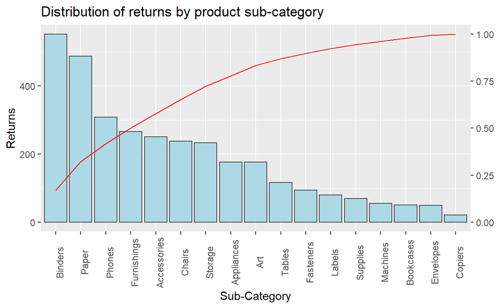

```r
scale <- 552
ggplot(data=freq_cum) +
  geom_col(aes(x = reorder(`Sub-Category`, -Returns), y = `Returns`),
           color='grey30',
           fill='lightblue')+
  geom_line(aes(x = reorder(`Sub-Category`, -Returns), y = `cumfreq`*scale/sum(Returns)),
            color='red',
            group=1)+
  theme(axis.text.x = element_text(angle = 90))+
  xlab('Sub-Category')+
  scale_y_continuous(name = 'Returns',
                     sec.axis = (~./scale))+
  ggtitle('Distribution of returns by product sub-category')
```

# Task 2: Population Pyramid

## Data Import

In this exercise, *respopagesextod2021* data set will be used.

The code chunk below imports respopagesextod2021.csv into R environment by using [read_csv()](https://readr.tidyverse.org/reference/read_delim.html) function of **readr** package.

```r
pop_data <- read_csv("Data/respopagesextod2021.csv")
```

## Data Wrangling

### Compute population by sex and age group

```r
pop_group <- pop_data %>%
  group_by(`AG`, `Sex`) %>%
  summarise('Population' = sum(`Pop`)) %>%
  ungroup()
```

## Plotting the pyramid

In the code chunk below, geom_col() is used to plot a bar chart by using population as the x-axis and age as the y-axis. An *ifelse* argument is inserted to make the male population inversed so as to creat the pyramid shape.

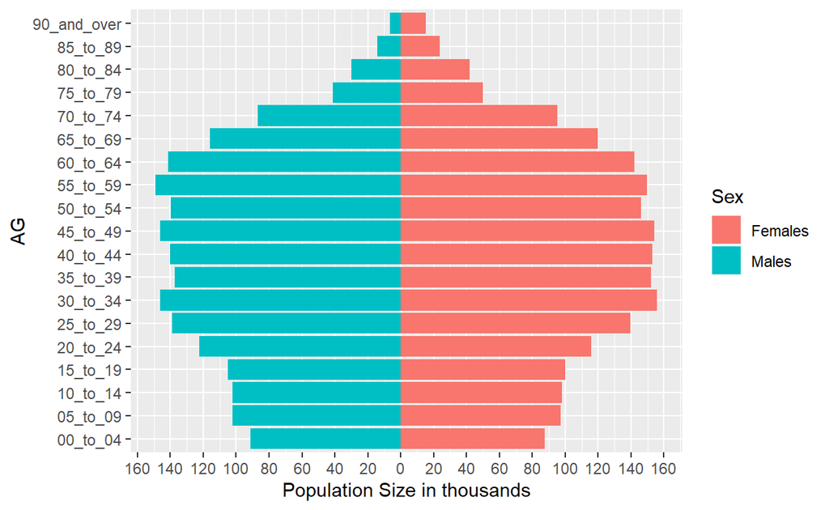

```r
ggplot(data=pop_group,
       aes(x = ifelse(test = Sex == 'Males',
                      yes = -Population/1000,
                      no = Population/1000),
                           y = AG, fill = Sex))+
  geom_col()+
  scale_x_continuous(breaks=seq(-160,160,20),labels = abs(seq(-160,160,20)))+
  labs(x = "Population Size in thousands")
```